# M3TimeSeriesDecompositions - Public Construction

Importing necessary packages and reducing the data to Public Construction for analysis. Using the equation:

S(𝑚) = 𝑇(𝑚) + 𝐶(𝑚) + 𝜖(𝑚)

Where S = Spending, T = Trend, C = Cyclical, and 𝜖 = error. All components are monthly.

```python
import pandas as pd
import matplotlib.pyplot as plt
import numpy as np
from scipy import stats
%matplotlib inline
dfConstrSpnd2 = pd.read_csv('C:/Users/robby/Documents/Business Analytics/CTBA/M3/ConstructionTimeSeriesDataV2.csv')
dfConstrSpnd2.drop(['Total Construction'],axis=1,inplace=True)
dfConstrSpnd2.drop(['Private Construction'],axis=1,inplace=True)
dfConstrSpnd2.head()
```

|  | Month | Month-Year | Public Construction |
| --- | --- | --- | --- |
| 0 | 1 | Jan-02 | 14243 |
| 1 | 2 | Feb-02 | 14113 |
| 2 | 3 | Mar-02 | 14386 |
| 3 | 4 | Apr-02 | 16221 |
| 4 | 5 | May-02 | 18375 |

Looking at a simple graph of the data.

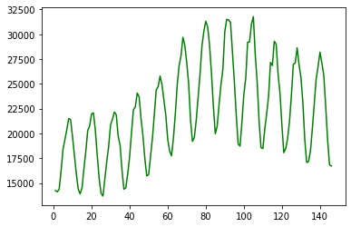

```python
fig,ax = plt.subplots()
ax.plot(dfConstrSpnd2['Month'],dfConstrSpnd2['Public Construction'],c='g')
```

Creating dates for the analysis that are also usable programmatically.

```python
dfConstrSpnd2.index = pd.period_range(freq = 'm', start = pd.Timestamp(year = 2002, month = 1, day = 31),
    periods = len(dfConstrSpnd2['Public Construction']))
dfConstrSpnd2.index = dfConstrSpnd2.index.astype(str)
print(dfConstrSpnd2.index)
```

```
Index(['2002-01', '2002-02', '2002-03', '2002-04', '2002-05', '2002-06',
       '2002-07', '2002-08', '2002-09', '2002-10',
       ...
       '2013-05', '2013-06', '2013-07', '2013-08', '2013-09', '2013-10',
       '2013-11', '2013-12', '2014-01', '2014-02'],
      dtype='object', length=146)
```

Constructing a period of time to have a moving average, to avoid a changing economy impacting older data too harshly. Determing the moving average and square error. First and last 18 months removed, since they could not be calculated (nothing before or after them to use in the equations).

```python
def sqErr(row):
    return (row['Public Construction'] - row['MovAvg'])**2

dfConstrSpnd2['MovAvgPub'] = np.NaN
dfConstrSpnd2['SqErrPub'] = np.NaN

window = 36
window = window - window % 2
for i in range(int(window/2),dfConstrSpnd2.shape[0]-int(window/2)):
    dfConstrSpnd2.loc[dfConstrSpnd2.index[i],'MovAvgPub'] = (0.5*dfConstrSpnd2.iloc[i - int(window/2)]['Public Construction'] +
    dfConstrSpnd2.iloc[i - int(window/2) + 1:i + int(window/2)]['Public Construction'].sum() +
    0.5*dfConstrSpnd2.iloc[i + int(window/2)]['Public Construction'])/float(window)
dfConstrSpnd2['SqErrPub'] = (dfConstrSpnd2['Public Construction'] - dfConstrSpnd2['MovAvgPub'])**2
dfConstrSpnd2.dropna(how='any',inplace=True)
```

The below graph also how we are still following the trend of the data and accurate to the source.

```
Average Squared Error per Month:  13581548.10100133
         Month Month-Year  Public Construction     MovAvgPub      SqErrPub
2003-07     19     Jul-03                20755  18050.486111  7.314395e+06
2003-08     20     Aug-03                21957  18058.000000  1.520220e+07
2003-09     21     Sep-03                22075  18084.916667  1.592077e+07
2003-10     22     Oct-03                20321  18126.152778  4.817354e+06
2003-11     23     Nov-03                17801  18170.000000  1.361610e+05
...        ...        ...                  ...           ...           ...
2012-04    124     Apr-12                21259  23397.138889  4.571638e+06
2012-05    125     May-12                23898  23333.500000  3.186602e+05
2012-06    126     Jun-12                26975  23272.680556  1.370717e+07
2012-07    127     Jul-12                27104  23222.000000  1.506992e+07
2012-08    128     Aug-12                28640  23173.416667  2.988353e+07

[110 rows x 5 columns]
```

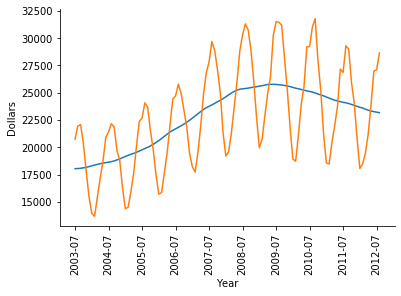

```python
fig,ax = plt.subplots()
ax.plot(dfConstrSpnd2['MovAvgPub'], label = 'Moving Avg.')
ax.plot(dfConstrSpnd2['Public Construction'], label='Spending on Public Construction')
ax.set_xlabel('Year')
ax.set_ylabel('Dollars')
ax.set_xticks(dfConstrSpnd2.index[::12])
ax.set_xticklabels(dfConstrSpnd2.index[::12], rotation = 90)
ax.spines['right'].set_visible(False)
ax.spines['top'].set_visible(False)
print('Average Squared Error per Month: ',sum(dfConstrSpnd2['SqErrPub'])/len(dfConstrSpnd2))
print(dfConstrSpnd2)
```

Removing the moving average from the data to see our unexplained data, such as the cyclical component and errors.

```python
dfConstrSpnd2['R1Public'] = dfConstrSpnd2['Public Construction'] - dfConstrSpnd2['MovAvgPub']
dfConstrSpnd2['R1ErrorPub'] = abs((dfConstrSpnd2['Public Construction'] - dfConstrSpnd2['R1Public'])/dfConstrSpnd2['Public Construction'])
dfConstrSpnd2.style.format({
    'MovAvg': '{:.1f}'.format,
    'sqErr': '{:,.1f}'.format,
    'R1': '{:,.1f}'.format,
    'R1Error': '{:,.3f}'.format
})
```

|  | Month | Month-Year | Public Construction | MovAvgPub | SqErrPub | R1Public | R1ErrorPub |
| --- | --- | --- | --- | --- | --- | --- | --- |
| 2003-07 | 19 | Jul-03 | 20755 | 18050.486111 | 7314395.375193 | 2704.513889 | 0.869693 |
| 2003-08 | 20 | Aug-03 | 21957 | 18058.000000 | 15202201.000000 | 3899.000000 | 0.822426 |
| 2003-09 | 21 | Sep-03 | 22075 | 18084.916667 | 15920765.006944 | 3990.083333 | 0.819249 |
| 2003-10 | 22 | Oct-03 | 20321 | 18126.152778 | 4817354.328897 | 2194.847222 | 0.891991 |
| 2003-11 | 23 | Nov-03 | 17801 | 18170.000000 | 136161.000000 | -369.000000 | 1.020729 |
| 2003-12 | 24 | Dec-03 | 15466 | 18235.500000 | 7670130.250000 | -2769.500000 | 1.179070 |
| 2004-01 | 25 | Jan-04 | 13959 | 18309.166667 | 18923950.027778 | -4350.166667 | 1.311639 |
| 2004-02 | 26 | Feb-04 | 13689 | 18376.958333 | 21976953.335069 | -4687.958333 | 1.342462 |
| 2004-03 | 27 | Mar-04 | 15443 | 18444.611111 | 9009669.262346 | -3001.611111 | 1.194367 |
| 2004-04 | 28 | Apr-04 | 17177 | 18502.000000 | 1755625.000000 | -1325.000000 | 1.077138 |
| 2004-05 | 29 | May-04 | 18709 | 18554.736111 | 23797.347415 | 154.263889 | 0.991755 |
| 2004-06 | 30 | Jun-04 | 20893 | 18603.111111 | 5243591.123457 | 2289.888889 | 0.890399 |
| 2004-07 | 31 | Jul-04 | 21444 | 18642.458333 | 7848635.710069 | 2801.541667 | 0.869355 |
| 2004-08 | 32 | Aug-04 | 22164 | 18687.819444 | 12083831.254823 | 3476.180556 | 0.843161 |
| 2004-09 | 33 | Sep-04 | 21876 | 18759.111111 | 9714996.345679 | 3116.888889 | 0.857520 |
| 2004-10 | 34 | Oct-04 | 19726 | 18846.361111 | 773764.574846 | 879.638889 | 0.955407 |
| 2004-11 | 35 | Nov-04 | 18809 | 18942.472222 | 17814.834105 | -133.472222 | 1.007096 |
| 2004-12 | 36 | Dec-04 | 16295 | 19052.611111 | 7604419.040123 | -2757.611111 | 1.169231 |
| 2005-01 | 37 | Jan-05 | 14380 | 19164.805556 | 22894364.204475 | -4784.805556 | 1.332740 |
| 2005-02 | 38 | Feb-05 | 14517 | 19273.083333 | 22620328.673611 | -4756.083333 | 1.327622 |
| 2005-03 | 39 | Mar-05 | 15920 | 19365.805556 | 11873575.926698 | -3445.805556 | 1.216445 |
| 2005-04 | 40 | Apr-05 | 17656 | 19447.902778 | 3210915.565008 | -1791.902778 | 1.101490 |
| 2005-05 | 41 | May-05 | 20097 | 19547.069444 | 302423.615934 | 549.930556 | 0.972636 |
| 2005-06 | 42 | Jun-05 | 22375 | 19659.222222 | 7375448.938272 | 2715.777778 | 0.878624 |
| 2005-07 | 43 | Jul-05 | 22679 | 19774.277778 | 8437411.188272 | 2904.722222 | 0.871920 |
| 2005-08 | 44 | Aug-05 | 24078 | 19890.069444 | 17538762.338156 | 4187.930556 | 0.826068 |
| 2005-09 | 45 | Sep-05 | 23685 | 20002.722222 | 13559169.632716 | 3682.277778 | 0.844531 |
| 2005-10 | 46 | Oct-05 | 21519 | 20125.291667 | 1942422.918403 | 1393.708333 | 0.935234 |
| 2005-11 | 47 | Nov-05 | 19775 | 20276.750000 | 251753.062500 | -501.750000 | 1.025373 |
| 2005-12 | 48 | Dec-05 | 17479 | 20444.583333 | 8794684.506944 | -2965.583333 | 1.169666 |

[output cut: 80 more lines]

A visualization of the remaining unexplained data.

```
Average Residual:  22864.51818181818
```

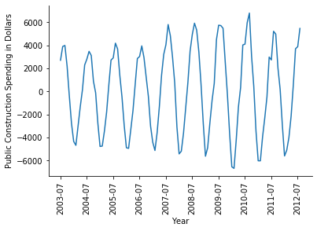

```python
fig,ax = plt.subplots()
ax.plot(dfConstrSpnd2['R1Public'])
ax.set_xlabel('Year')
ax.set_ylabel('Public Construction Spending in Dollars')
ax.set_xticks(dfConstrSpnd2.index[::12])
ax.set_xticklabels(dfConstrSpnd2.index[::12], rotation = 90)
ax.spines['right'].set_visible(False)
ax.spines['top'].set_visible(False)
print('Average Residual: ', sum(dfConstrSpnd2['Public Construction'])/len(dfConstrSpnd2))
```

Determining the cyclical component from earlier.

```python
maxCorr = 0.0
period = np.NaN
for i in range(1,37):
    corr = dfConstrSpnd2['R1Public'].autocorr(lag=i)
    print('Correlation, lag ',i,'   ',corr)
    if corr > maxCorr:
        maxCorr = corr
        period = i
print('period = ',period,'     Maximum Correlation = ',maxCorr)
```

```
Correlation, lag  1     0.8486375316894602
Correlation, lag  2     0.4846195337567183
Correlation, lag  3     -0.007177248780703143
Correlation, lag  4     -0.49554892375973447
Correlation, lag  5     -0.8288179569669593
Correlation, lag  6     -0.9462777407123573
Correlation, lag  7     -0.8288579638039721
Correlation, lag  8     -0.48571061970010343
Correlation, lag  9     0.004997098591155971
Correlation, lag  10     0.4817646196968951
Correlation, lag  11     0.8389178942275625
Correlation, lag  12     0.9802446550357118
Correlation, lag  13     0.8361843883266434
Correlation, lag  14     0.4848265284305894
Correlation, lag  15     -0.003592213269114516
Correlation, lag  16     -0.48222336701850393
Correlation, lag  17     -0.8171150144686051
Correlation, lag  18     -0.9427534781166457
Correlation, lag  19     -0.8337051906400711
Correlation, lag  20     -0.4961430024835644
Correlation, lag  21     -0.009858447978117565
Correlation, lag  22     0.4684416329134112
Correlation, lag  23     0.8266661876059614
Correlation, lag  24     0.9712553048735744
Correlation, lag  25     0.8438762290583999
Correlation, lag  26     0.4966059057862167
Correlation, lag  27     0.00363557405229584
Correlation, lag  28     -0.47760887383472916
Correlation, lag  29     -0.8193773652675437
Correlation, lag  30     -0.9507330427079982
Correlation, lag  31     -0.8506201153800946
Correlation, lag  32     -0.5192149782007527
Correlation, lag  33     -0.03281414568805165
Correlation, lag  34     0.4561413678718069
Correlation, lag  35     0.8151545937149086
Correlation, lag  36     0.9633718688320395
period =  12      Maximum Correlation =  0.9802446550357118
```

Period of 36 to see multiple years of datae. A visual comparison to the average cycle to confirm the findings. Based on previous graphs, I expect the cycle to be yearly.

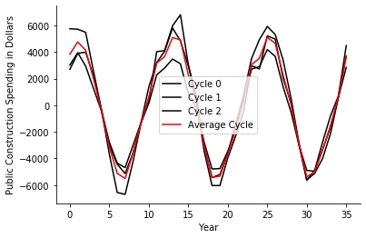

```python
period = 36
cycleLen = period
numCycles = int(len(dfConstrSpnd2)/cycleLen + 0.5)
cycles = [dfConstrSpnd2.iloc[range(i*period,min((i+1)*period,len(dfConstrSpnd2)))]['R1Public'] for i in range(numCycles)]
ptsInCycles = [dfConstrSpnd2.iloc[range(i,len(dfConstrSpnd2['R1Public']),period)]['R1Public'].tolist() for i in range(period)]
avg = [sum(pts)/len(pts) for pts in ptsInCycles]

fig,ax = plt.subplots()
for i in range(len(cycles)):
    ax.plot(cycles[i].values,label='Cycle '+str(i),c='k')
ax.plot(avg,label='Average Cycle',c='r')
ax.set_xlabel('Year')
ax.set_ylabel('Public Construction Spending in Dollars')
ax.spines['right'].set_visible(False)
ax.spines['top'].set_visible(False)
ax.legend()
```

Determination and graphing of the Cyclical component to Public Construction Spending. Graphed with all of the remainder to show significance of the Cyclical component.

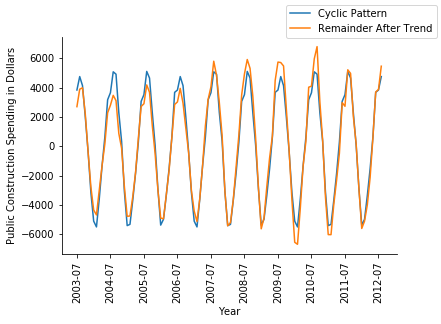

```python
cycleLen = period
numCycles = int(len(dfConstrSpnd2)/cycleLen + 0.5)
dfConstrSpnd2['CyclicPub'] = np.NaN
for i in range(len(dfConstrSpnd2)):
    dfConstrSpnd2.loc[dfConstrSpnd2.index[i], 'CyclicPub'] = avg[i % cycleLen]

fig,ax = plt.subplots()
ax.plot(dfConstrSpnd2['CyclicPub'],label='Cyclic Pattern')
ax.plot(dfConstrSpnd2['R1Public'],label='Remainder After Trend')
ax.set_xlabel('Year')
ax.set_ylabel('Public Construction Spending in Dollars')
ax.set_xticks(dfConstrSpnd2.index[::12])
ax.set_xticklabels(dfConstrSpnd2.index[::12], rotation = 90)
ax.spines['right'].set_visible(False)
ax.spines['top'].set_visible(False)
fig.legend()
```

Removing the Cyclical component. Determining R2 Error. Comparing my values (moving average plus cyclical component) to the original line, Public Construction amounts, showing the error.

```
Average Error:  0.023224970271695
         Month Month-Year  Public Construction     MovAvgPub      SqErrPub  \
2003-07     19     Jul-03                20755  18050.486111  7.314395e+06
2003-08     20     Aug-03                21957  18058.000000  1.520220e+07
2003-09     21     Sep-03                22075  18084.916667  1.592077e+07
2003-10     22     Oct-03                20321  18126.152778  4.817354e+06
2003-11     23     Nov-03                17801  18170.000000  1.361610e+05
...        ...        ...                  ...           ...           ...
2012-04    124     Apr-12                21259  23397.138889  4.571638e+06
2012-05    125     May-12                23898  23333.500000  3.186602e+05
2012-06    126     Jun-12                26975  23272.680556  1.370717e+07
2012-07    127     Jul-12                27104  23222.000000  1.506992e+07
2012-08    128     Aug-12                28640  23173.416667  2.988353e+07

            R1Public  R1ErrorPub    CyclicPub     R2Public  R2ErrorPublic  \
2003-07  2704.513889    0.869693  3840.788194 -1136.274306       0.054747
2003-08  3899.000000    0.822426  4758.486111  -859.486111       0.039144
2003-09  3990.083333    0.819249  4138.800926  -148.717593       0.006737
2003-10  2194.847222    0.891991  1996.861111   197.986111       0.009743
2003-11  -369.000000    1.020729  -367.620370    -1.379630       0.000078
...              ...         ...          ...          ...            ...
2012-04 -2138.138889    1.100576 -1535.328704  -602.810185       0.028356
2012-05   564.500000    0.976379   623.240741   -58.740741       0.002458
2012-06  3702.319444    0.862750  3682.138889    20.180556       0.000748
2012-07  3882.000000    0.856774  3840.788194    41.211806       0.001521
2012-08  5466.583333    0.809128  4758.486111   708.097222       0.024724

               FitPub
2003-07  21891.274306
2003-08  22816.486111
2003-09  22223.717593
2003-10  20123.013889
2003-11  17802.379630
...               ...
2012-04  21861.810185
2012-05  23956.740741
2012-06  26954.819444
2012-07  27062.788194
2012-08  27931.902778

[110 rows x 11 columns]
```

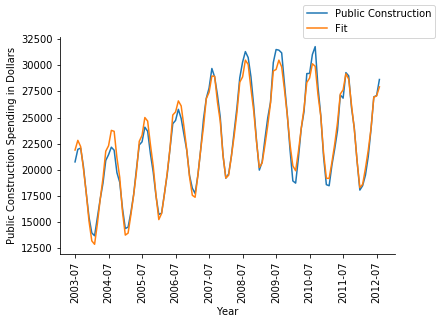

```python
dfConstrSpnd2['R2Public'] = dfConstrSpnd2['R1Public'] - dfConstrSpnd2['CyclicPub']
dfConstrSpnd2['R2ErrorPublic'] = abs(dfConstrSpnd2['R2Public']/dfConstrSpnd2['Public Construction'])
dfConstrSpnd2['FitPub'] = dfConstrSpnd2['MovAvgPub'] + dfConstrSpnd2['CyclicPub']
print('Average Error: ', sum(dfConstrSpnd2['R2ErrorPublic'])/len(dfConstrSpnd2))
print(dfConstrSpnd2)
fig,ax = plt.subplots()
ax.plot(dfConstrSpnd2['Public Construction'], label='Public Construction')
ax.plot(dfConstrSpnd2['FitPub'], label = 'Fit')
ax.set_xlabel('Year')
ax.set_xticks(dfConstrSpnd2.index[::12])
ax.set_xticklabels(dfConstrSpnd2.index[::12], rotation = 90)
ax.set_ylabel('Public Construction Spending in Dollars')
ax.spines['right'].set_visible(False)
ax.spines['top'].set_visible(False)
fig.legend()
```